# Argus Media - Oil Dataset Project

### COMPARING PREDICTION IN A RANGE OF 0,5% DEVIATION

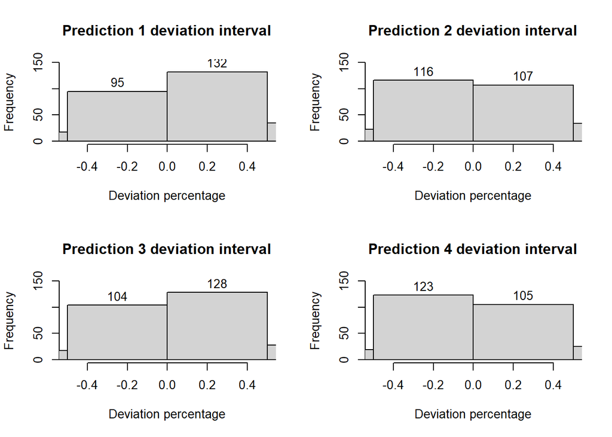

```r
par(mfrow=c(2,2))
hist(100*testset_DF$pred.deviation_1, main="Prediction 1 deviation interval", xlab = "Deviation percentage", labels = T, xlim =c(-0.5,0.5), ylim = c(0,150))
hist(100*testset_OIL$pred.deviation_2, main="Prediction 2 deviation interval", xlab = "Deviation percentage", labels = T, xlim =c(-0.5,0.5), ylim = c(0,150))
hist(100*testset_DF$pred.deviation_3, main="Prediction 3 deviation interval", xlab = "Deviation percentage", labels = T, xlim =c(-0.5,0.5), ylim = c(0,150))
hist(100*testset_OIL$pred.deviation_4, main="Prediction 4 deviation interval", xlab = "Deviation percentage", labels = T, xlim =c(-0.5,0.5), ylim = c(0,150))
```

0,5% prediction deviation:

The df dataset shows better results.

### RESIDUALS VISUALIZATION

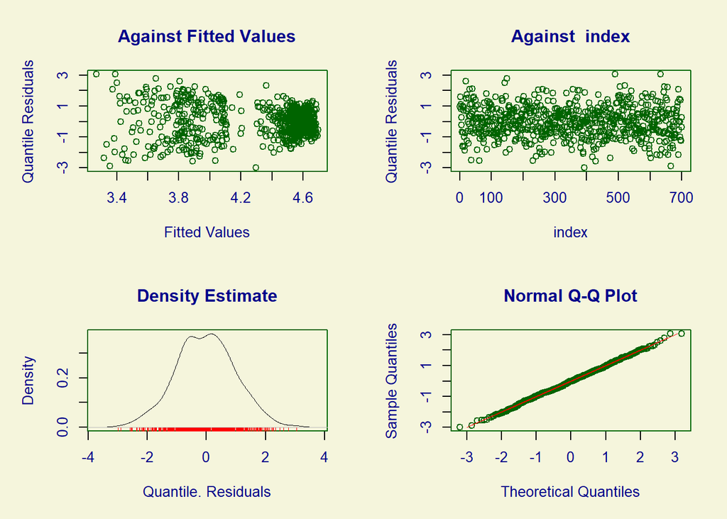

```
##        Summary of the Quantile Residuals
##                            mean   =  -0.02787053
##                        variance   =  1.000378
##                coef. of skewness  =  0.02687419
##                coef. of kurtosis  =  2.964467
## Filliben correlation coefficient  =  0.999444
```

```r
plot(mod_1)
```

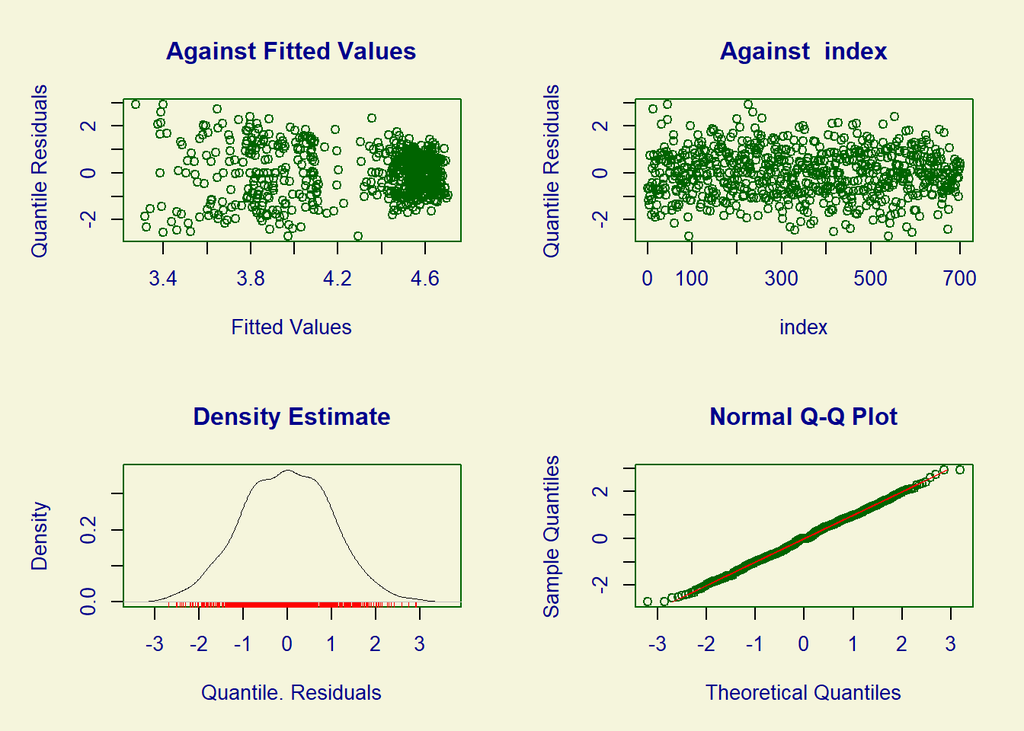

```
##        Summary of the Quantile Residuals
##                            mean   =  -0.02119448
##                        variance   =  0.9958681
##                coef. of skewness  =  0.002554126
##                coef. of kurtosis  =  2.777229
## Filliben correlation coefficient  =  0.9991326
```

```r
plot(mod_2)
```

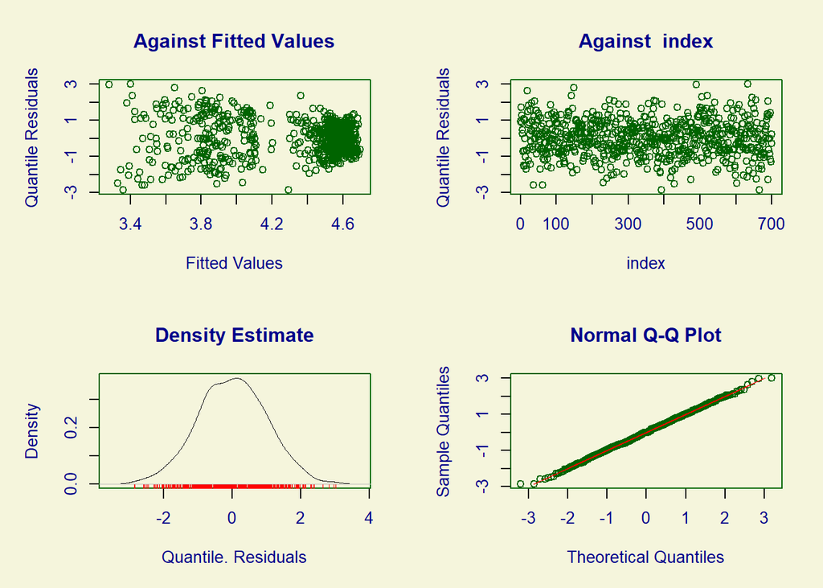

```
##        Summary of the Quantile Residuals
##                            mean   =  0.00148179
##                        variance   =  0.9990634
##                coef. of skewness  =  -0.0003989181
##                coef. of kurtosis  =  2.904013
## Filliben correlation coefficient  =  0.9995973
```

```r
plot(mod_3)
```

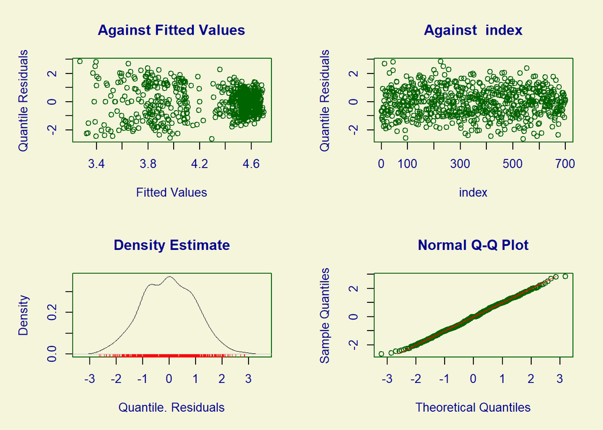

```
##        Summary of the Quantile Residuals
##                            mean   =  -0.03351561
##                        variance   =  0.9928264
##                coef. of skewness  =  0.0183582
##                coef. of kurtosis  =  2.677545
## Filliben correlation coefficient  =  0.9987439
```

```r
plot(mod_4)
```

It’s possible to visualize the model’s residuals have a normal distribution and do not deviate much from the parameters. In this regard, we can’t cut off any model for bad performance.

WORM PLOT

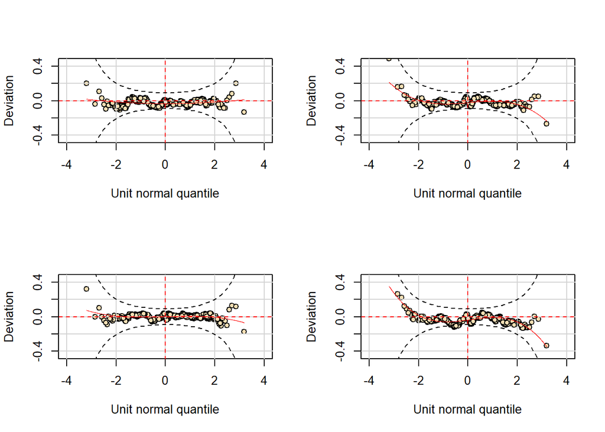

```r
# Plotting residuals

par(mfrow=c(2,2))
wp(mod_1)
wp(mod_2)
wp(mod_3)
wp(mod_4)
```

The same condition happens here. All model’s residuals follow the trend line. Some of them have a different trend line, but It happens because some models have more variables fitted than others. So it’s normal to have more variance and a different trend line. However, all of them have followed it correctly.

NON PARAMETRIC TESTS

```r
# Getting each model's non parametric test

GD = c(mod_1$G.deviance,mod_2$G.deviance,mod_3$G.deviance,mod_4$G.deviance)#Deviation
AIC = c(mod_1$aic,mod_2$aic,mod_3$aic,mod_4$aic)# Overfitting
SBC = c(mod_1$sbc,mod_3$sbc,mod_4$sbc,mod_4$sbc)# Overfitting

GD # First Line
```

```
## [1] -3459.462 -3515.960 -3489.267 -3529.237
```

```r
AIC # Second line
```

```
## [1] -3431.462 -3459.960 -3427.264 -3383.245
```

```r
SBC # Third line
```

```
## [1] -3367.747 -3286.172 -3051.034 -3051.034
```

```r
# 1 model           #2 model           #3 model          # 4 model
```